# Boston_tutorial

###### step13: XのRM（平均部屋数）を横軸に、yのMEDV（住宅価格の中央値）を縦軸にした散布図を表示する

住宅当たりの平均部屋数が多い町ほど、住宅価格の中央値が高い傾向にある、という仮説が考えられます。  
そこで、これらの2次元グラフを描いてそれを確かめてみます。  
横軸に住宅当たりの平均部屋数、縦軸に住宅価格の中央値をとって散布図を描きます。

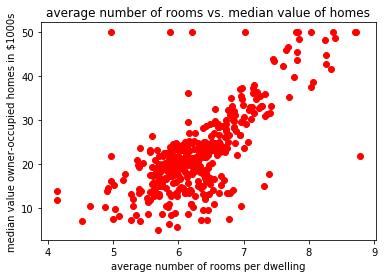

```python
plt.title("average number of rooms vs. median value of homes") #グラフのタイトルを設定（日本語は表示不可）
plt.xlabel("average number of rooms per dwelling") #横軸にラベルを設定
plt.ylabel("median value owner-occupied homes in $1000s") #縦軸にラベルを設定
plt.scatter(x = X["RM"], y = y["MEDV"], marker = "o", color= "red") #散布図を生成
plt.show() #生成した散布図を表示
```

横軸の値が大きいほど平均部屋数が多く、縦軸の値が大きいほど住宅価格の中央値が高いことを表します。  
グラフから、部屋数と住宅価格は正の関係を持ちそうです。

X中の項目(CRIM, ZN, INDUS, CHAS, ...)の値からこのMEDVを予測することを試みます。  
ここでは、線形回帰モデルを用いて予測します。

###### step14: 線形回帰で住宅価格を予測するためのデータ前処理

```python
#sklearn: 機械学習機能ライブラリ
#sklearn.preprocessing: データの前処理パッケージ
from sklearn.preprocessing import StandardScaler

sc = StandardScaler() #sc: 正規化
sc.fit(X) #Xの平均、標準偏差などの統計情報を計算

X_std =sc.transform(X) #X_std
```

```python
#X_std: X_stdのデータフレーム版
X_std = pd.DataFrame(X_std, columns = X.columns, index = X.index)
```

```python
X_std.head() #X_stdの先頭5行を表示
```

| town | CRIM | ZN | INDUS | CHAS | NOX | RM | AGE | DIS | RAD | TAX | PTRATIO | B | LSTAT |
| --- | --- | --- | --- | --- | --- | --- | --- | --- | --- | --- | --- | --- | --- |
| 1 | -0.386223 | -0.490103 | -0.174449 | -0.283221 | -0.070088 | -0.287273 | 0.943335 | -0.593431 | -0.416406 | 0.131159 | -0.329600 | 0.445228 | 0.616820 |
| 2 | 0.550723 | -0.490103 | 0.993487 | -0.283221 | 0.246642 | -1.053341 | 0.059674 | -0.817498 | 1.644931 | 1.511302 | 0.804065 | -4.015544 | 0.626847 |
| 3 | -0.350369 | 0.369652 | -1.046432 | -0.283221 | 0.785941 | 1.332079 | 0.807935 | -0.879191 | -0.530925 | -0.859714 | -2.596931 | 0.343024 | -0.671007 |
| 4 | -0.408866 | 2.948917 | -1.329393 | -0.283221 | -1.028841 | 0.502052 | -1.397654 | 2.087047 | -0.645443 | -0.765345 | -0.707489 | 0.377621 | -0.973266 |
| 5 | 0.184365 | -0.490103 | 0.993487 | -0.283221 | 1.350920 | 0.531125 | 1.043103 | -0.682595 | 1.644931 | 1.511302 | 0.804065 | -0.026769 | 0.708500 |

###### step15: 線形回帰モデルをX_stdとyにフィットさせる

```python
#sklearn.linear_model: 線形モデルパッケージ
from sklearn.linear_model import LinearRegression #LinearRegression: 線形回帰

lr = LinearRegression() #lr: 定義された線形回帰関数(linear regression)
lr.fit(X_std, y) #lrをX_std, y にフィット
```

```
LinearRegression(copy_X=True, fit_intercept=True, n_jobs=1, normalize=False)
```

```python
#（標準）回帰係数とその説明変数を表示
print(pd.DataFrame({"Columns": X.columns, "Coefficients": lr.coef_[0]}))
print("Intercept = ", lr.intercept_) #切片の値を表示
```

```
    Coefficients  Columns
0      -0.877056     CRIM
1       0.962975       ZN
2      -0.191004    INDUS
3       0.604486     CHAS
4      -1.581743      NOX
5       2.914290       RM
6      -0.444990      AGE
7      -3.214817      DIS
8       2.338563      RAD
9      -2.307202      TAX
10     -1.502468  PTRATIO
11      1.004815        B
12     -3.420487    LSTAT
Intercept =  [22.21831683]
```

線形回帰モデルをフィットさせたあとの、各変数に対する回帰係数の大きさの表です。

係数の絶対値が、その変数の関係の強さを表しています。  
係数の符号が正であれば、正の関係にあるといえます。  
逆に符号が負であれば、負の関係にあるといえます。

AとBに正の関係にあるとは、Aの値が大きくなればBの値も大きくなる、ということを意味します。 逆もまた然りです。  
一方、負の関係にあるとは、Aの値が大きくなればBの値は小さくなる、ということを意味します。

表から、係数の絶対値が1以上の場合に強い関係にある、といえるとすると、  
RM, RAD, BがMEDVと強い正の関係にあります。  
step13で見られたRM（平均部屋数）とMEDV（住宅価格の中央値）の正の関係が、ここでも確認できます。

一方表から、LSTAT, DIS, TAX, NOX, RTRATIOが強い負の関係にあります。  
LSTAT（低所得者層割合）が大きい町ほどMEDV（住宅価格の中央値）が低くなる傾向が確認できます。

係数の標準偏差や決定係数など、回帰結果をより詳細に見る方法は、ページ最下部に補足しています。

上の係数と切片を持つ線形回帰モデルを使って、コンペ用データ(CRIM, ZN, ...)が入ったときのMEDVを予測します。

###### step16: コンペ用データを読み込み、X_compに入れる

```python
#X_comp: 102個, 13項目のコンペ用データ
X_comp = pd.read_csv(os.path.join('spring-school-2018', 'private_data.csv'), index_col=0)
```

```python
X_comp.shape #X_compの大きさを表示
```

```
(102, 13)
```

```python
X_comp.head() #X_compの先頭5行を表示
```

| town | CRIM | ZN | INDUS | CHAS | NOX | RM | AGE | DIS | RAD | TAX | PTRATIO | B | LSTAT |
| --- | --- | --- | --- | --- | --- | --- | --- | --- | --- | --- | --- | --- | --- |
| 405 | 0.21409 | 22.0 | 5.86 | 0.0 | 0.431 | 6.438 | 8.9 | 7.3967 | 7.0 | 330.0 | 19.1 | 377.07 | 3.59 |
| 406 | 0.22969 | 0.0 | 10.59 | 0.0 | 0.489 | 6.326 | 52.5 | 4.3549 | 4.0 | 277.0 | 18.6 | 394.87 | 10.97 |
| 407 | 1.22358 | 0.0 | 19.58 | 0.0 | 0.605 | 6.943 | 97.4 | 1.8773 | 5.0 | 403.0 | 14.7 | 363.43 | 4.59 |
| 408 | 1.46336 | 0.0 | 19.58 | 0.0 | 0.605 | 7.489 | 90.8 | 1.9709 | 5.0 | 403.0 | 14.7 | 374.43 | 1.73 |
| 409 | 0.07151 | 0.0 | 4.49 | 0.0 | 0.449 | 6.121 | 56.8 | 3.7476 | 3.0 | 247.0 | 18.5 | 395.15 | 8.44 |

###### step17: X_compを正規化し、X_comp_stdに入れる

正規化したデータで学習させたので、新たに予測する場合も正規化したデータを入れます。  
正規化する際の平均や標準偏差の情報は、学習用データのものを用います。(step14)

```python
X_comp_std = sc.transform(X_comp) #X_comp_std: 正規化済みコンペ用データ
```

###### step18: X_comp_stdから予測を立て、y_comp_predに予測値を入れる

```python
#y_comp_pred: X_comp_stdに対して、住宅価格の中央値の予測値（正解は参加者には分からない）(LR)
y_comp_pred = lr.predict(X_comp_std) #lr.predict()でフィット済みのlrを使って予測値を出力
```

```python
y_comp_pred[:5] #予測値を5つ目まで表示
```

```
array([[25.61228345],
       [24.00037915],
       [31.76083215],
       [35.54310308],
       [26.14590554]])
```

ここまででコンペ用データに対して予測ができました。  
この予測がどれだけ良いものなのか、以下step19 - step24の手順を踏んで、コンペサイトに提出して確認します。

###### step19: y_comp_predをファイル (submission_boston.dat) に書き込む

```python
import numpy as np #np: データ操作機能ライブラリ

#"submission_boston.dat"という名前で予測結果を保存
#savetxt: 変数をファイルに保存
np.savetxt("submission_boston.dat", y_comp_pred, fmt="%.6f")
```

###### step20: submission_boston.datをローカルにダウンロードする

```python
from google.colab import files #google.colab: google colab操作パッケージ
files.download("submission_boston.dat") #ファイルをローカルにダウンロード
```

ローカルに保存したsubmission_boston.datをコンペティションサイトで提出します。

###### step21: コンペティションサイト（http://universityofbigdata.net) にアクセスする

###### step22: トップページ右上、「参加登録する」をクリックし、サイトに登録する

（英語の場合は”Sign up with Google Account”） （登録済みの場合、次のstepへ。）

###### step23: トップページ中部、「課題① 回帰問題チャレンジ」をクリックし、課題ページに移る

###### step24:

###### 画面中部、「予測結果の提出」の下の空欄をクリックし、先ほどのsubmission_boston.datを選択し、

###### 右の"submit"ボタンをクリックする

画面にスコアが表示されます。  
このスコアは真の値と予測結果の値のRMSE（平均二乗誤差の平方根）です。  
つまりスコアの値が小さいほどよい予測といえます。  
このチュートリアルの方法では、5.99143です。  
step12のヒストグラムから、MEDVの値は10-50の分布を取るので、この予測はまずますといえます。

これで提出完了です。お疲れ様でした。  
提出回数はお一人様10回までです。

Error: Bad Request

The upload URL has expired.

と出たときは、もう一度トップページから入り直してください。

### 他のモデルの利用

この線形回帰に正則化項を加えたモデルを利用してみます。

###### step25: 線形回帰に正則化項を加えたモデルを利用する

```python
#sklearn.linear_model: 線形モデルパッケージ
from sklearn.linear_model import SGDRegressor #SGDRegressor: 線形回帰+正則化項
```

SGDRegressor()で、様々な線形回帰（+正則化項）が実現できます。

パラメータpenaltyで正則化項を指定できます。  
"none" = 正則化項なし = 線形回帰（step15 - step18と同じ）  
"l1" = L1正則化項 = Lasso回帰  
"l2" = L2正則化項 = Ridge回帰  
"elasticnet" = L1正則化項 + L2正則化項 = Elastic Net回帰

パラメータalphaで正則化項の係数を指定できます。

ためしにpenalty = "l2"、alpha = 0.1としてSGDRegressor()を使ってみます。

```python
sgd = SGDRegressor(penalty = "l2", alpha = 0.1, max_iter = 1000, random_state = 777)
```

```python
sgd.fit(X_std, np.ravel(y)) #データにフィットさせる、yでもOK（ただし注意メッセージが出る）
y_comp_pred_sgd = sgd.predict(X_comp_std) #y_comp_pred_sgd: コンペ用データについての予測値(SGD)
```

```python
y_comp_pred_sgd #予測値
```

```
array([25.96401534, 23.89188681, 30.95560176, 34.66719865, 25.6004325 ,
       25.27613328, 21.21122605, 32.89852209, 25.36723766, 35.47475403,
       22.71367567, 27.27277693, 12.63201286,  7.26934262, 23.34874734,
       21.77927837, 14.95141879,  5.57913192, 19.14886825, 42.62042224,
       13.17345214, 20.97684015, 22.73155001, 21.65254903,  0.23161577,
       23.4530718 , 12.48890702, 21.22722661, 23.50024644, 25.81403965,
       12.03946983,  7.21372001, 18.74107169, 39.6886191 ,  5.49848498,
       17.47168966, 17.66643729, 30.13208373, 14.59017221, 16.05105521,
       32.44336622, 18.25861939, 25.44716601, 13.42505548, 24.33298093,
       32.06200749, 24.53749063, 26.1741057 , 18.23353774, 27.97778123,
       21.03937888, 28.48395911, 20.71864168, 30.44221699, 31.95931067,
       27.16134284, 28.08373827, 19.78105099, 24.79408443, 26.5853955 ,
       12.91452112, 23.08546771, 21.54952123, 33.94803737, 16.66929746,
       16.13271985, 21.15216819, 35.77246923, 19.87087391, 20.58665337,
       24.85660726, 11.09447317, 25.38156297, 25.46762521, 33.57798584,
       30.83789568,  2.79019952, 23.96706502, 26.32073415, 23.1563177 ,
       33.7879548 , 25.4246007 , 30.37897965, 22.32895501, 21.83550693,
       17.41120412, 31.14139434, 22.36230109, 28.99178863, 29.61901407,
       39.19309234, 27.37030229, 30.488804  , 20.91505575, 14.7307059 ,
       33.40415742, 21.3403067 , 14.61298654, 12.89739386, 17.81976527,
       18.44786503,  9.93167133])
```

```python
np.savetxt("submission_boston_sgd.dat", y_comp_pred_sgd, fmt="%.6f") #savetxt: ファイルに保存
files.download("submission_boston_sgd.dat") #ファイルをローカルにダウンロード
```

submission_boston_sgd.datを提出すると、スコアは6.35760でした。  
step24での線形回帰よりも予測は悪くなっています。  
正則化項の影響が大きすぎてモデルがデータによくフィットできていないことが原因に挙げられます。  
SGDRegressorのパラメータalphaの値を変更すると改善されることが期待できます。

###### step26: 回帰木（決定木を用いた回帰）を利用する

説明変数（予測に利用する変数）と目的変数（予測したい変数）が線形の関係にあるとは限りません。  
非線形のモデルについても試してみます。  
今回は回帰木（決定木を用いた回帰）を利用します。

```python
from sklearn.tree import DecisionTreeRegressor #DecisionTreeRegressor: 回帰木

dtr = DecisionTreeRegressor(random_state = 777) #dtr: 回帰木を定義
dtr.fit(X_std, y) #fit()でデータにフィットさせる、決定木は説明変数を正規化しなくてよい
y_comp_pred_dtr = dtr.predict(X_comp_std) #y_comp_pred_dtr: コンペ用データについての予測値(DTR)
```

```python
y_comp_pred_dtr #予測値
```

```
array([24.5, 20.6, 22.8, 50. , 18.7, 25. , 20.4, 32.2, 22.6, 50. , 20.6,
       22.6, 11. , 21.9, 20.4, 18.7, 16.1,  7.2, 20.5, 42.3, 12.3, 16.6,
       21.1, 21.2, 17.2, 18.9, 27.1, 19. , 21.2, 24.2, 13.4,  8.5, 16.1,
       35.2, 14.5, 15.6, 15. , 29.8, 22.5, 12. , 37.9, 16.3, 29. , 13.8,
       18.7, 28.2, 21.4, 22.3, 19.4, 31.6, 21.2, 29. , 18.7, 24.1, 32.2,
       22.6, 22.9, 17.4, 25. , 22.4, 16.2, 15. , 22.9, 37.3, 27.1, 16.1,
       21.8, 35.2, 22.6, 20.4, 23.4, 20.6, 24.6, 18.6, 35.4, 33. , 10.5,
       23.4, 22.1, 21.1, 32.7, 23.1, 28.5, 20.2, 16.8, 10.5, 25. , 22.3,
       31.2, 50. , 42.3, 25. , 29.4, 19.4, 14.1, 35.4, 17. , 10.5, 13.4,
       12. , 22.6, 13.8])
```

```python
np.savetxt("submission_boston_dtr.dat", y_comp_pred_dtr, fmt="%.6f") #savetxt: ファイルに保存
files.download("submission_boston_dtr.dat") #ファイルをローカルにダウンロード
```

このsubmission_boston_dtr.datを提出すると、スコアは5.28746でした。  
線形回帰よりも良い予測ができています。

ここまで、コンペサイトに提出することで予測の良さを確認してきました。  
手元で確認できるようになると、試行錯誤がしやすくなります。  
そこで、データを学習に用いるデータと、テストに用いるデータに分割します。  
今後、このテストに用いるデータでモデルのパラメータの調整を行います。

###### step27: データを訓練用データ (X_train, y_train) とテスト用データ (X_test, y_test) の2つに分割する

```python
#train_test_split: データを2つに分割する
from sklearn.model_selection import train_test_split

#X_train, X_test: 訓練用Xとテスト用X
#y_train, y_test: 訓練用yとテスト用y
#train : test = 8 : 2 の比率で分ける
X_train, X_test, y_train, y_test = train_test_split(X_std, y, test_size=0.2, random_state=777)
```

```python
X_train.shape #元のXは404個だったが、323 (404 × 0.8)個になっている
```

```
(323, 13)
```

```python
y_train.shape #X_trainと同様
```

```
(323, 1)
```

```python
X_test.shape #元のXは404個だったが、81 (404 × 0.2)個になっている
```

```
(81, 13)
```

```python
y_test.shape #X_testと同様
```

```
(81, 1)
```

###### step28: (X_train, y_train)を用い、様々なパラメータで線形回帰+正則化項モデルを学習させる

step25で利用したSGDRegressor()を、今度は(X_train, y_train)で学習させ、X_testからy_testの値を予測します。

```python
sgd = SGDRegressor(penalty = "l2", alpha = 0.1, max_iter = 1000, random_state = 777)
sgd.fit(X_train, np.ravel(y_train)) #データにフィットさせる、y_trainでもOK（ただし注意メッセージが出る）
y_test_pred = sgd.predict(X_test) #y_test_pred: テスト用データについての予測値(SGD)
```

y_test_predに予測結果が入りました。  
これと真の値y_testの誤差を求めます。

###### step29: 予測の良さをテストする

```python
from sklearn.metrics import mean_squared_error #mean_squared_error: 平均二乗誤差

#y_testとy_test_predの平均二乗誤差の平方根を算出
np.sqrt(mean_squared_error(y_test, y_test_pred)) #np.sqrt: 平方根算出
```

```
6.915996026978186
```

###### step30: パラメータの値を変えて、step28 - step29を行う

パラメータalphaの値を0.01にして再試行します。

```python
#alpha = 0.01
sgd = SGDRegressor(penalty = "l2", alpha = 0.01, max_iter = 1000, random_state = 777)
sgd.fit(X_train, np.ravel(y_train)) #データにフィットさせる、y_trainでもOK（ただし注意メッセージが出る）
y_test_pred = sgd.predict(X_test) #y_test_pred: テスト用データについての予測値(SGD)

np.sqrt(mean_squared_error(y_test, y_test_pred)) #np.sqrt: 平方根算出
```

```
6.910121372241205
```

このように、パラメータの値を変えると予測結果も変わります。

# Bostonチュートリアル終了

### 補足

###### step15-2: 線形回帰結果を詳細に見る

```python
#statsmodels: 統計情報ライブラリ
import statsmodels.regression.linear_model as lm
```

```python
from sklearn.preprocessing import StandardScaler #sklearn.preprocessing: データの前処理パッケージ

X_std = StandardScaler().fit_transform(X) #X_std: Xの各項目の値を正規化
X_std = pd.DataFrame(X_std, columns = X.columns, index = X.index) #X_std
```

```python
X_std.head() #X_stdの先頭5行を表示
```

| town | CRIM | ZN | INDUS | CHAS | NOX | RM | AGE | DIS | RAD | TAX | PTRATIO | B | LSTAT |
| --- | --- | --- | --- | --- | --- | --- | --- | --- | --- | --- | --- | --- | --- |
| 1 | -0.386223 | -0.490103 | -0.174449 | -0.283221 | -0.070088 | -0.287273 | 0.943335 | -0.593431 | -0.416406 | 0.131159 | -0.329600 | 0.445228 | 0.616820 |
| 2 | 0.550723 | -0.490103 | 0.993487 | -0.283221 | 0.246642 | -1.053341 | 0.059674 | -0.817498 | 1.644931 | 1.511302 | 0.804065 | -4.015544 | 0.626847 |
| 3 | -0.350369 | 0.369652 | -1.046432 | -0.283221 | 0.785941 | 1.332079 | 0.807935 | -0.879191 | -0.530925 | -0.859714 | -2.596931 | 0.343024 | -0.671007 |
| 4 | -0.408866 | 2.948917 | -1.329393 | -0.283221 | -1.028841 | 0.502052 | -1.397654 | 2.087047 | -0.645443 | -0.765345 | -0.707489 | 0.377621 | -0.973266 |
| 5 | 0.184365 | -0.490103 | 0.993487 | -0.283221 | 1.350920 | 0.531125 | 1.043103 | -0.682595 | 1.644931 | 1.511302 | 0.804065 | -0.026769 | 0.708500 |

```python
#OLS: 線形回帰 (Ordinary Least Squares regression)
#説明変数 - X, 目的変数 - y として線形回帰
lr = lm.OLS(y, lm.add_constant(X_std), hasconst = True) #lr: 切片付きの線形回帰モデル（フィット済み）
```

```python
result = lr.fit() #result: 線形回帰結果
result.summary() #回帰結果を表示
```

OLS Regression Results

| Dep. Variable: | MEDV | R-squared: | 0.749 |
| --- | --- | --- | --- |
| Model: | OLS | Adj. R-squared: | 0.741 |
| Method: | Least Squares | F-statistic: | 89.53 |
| Date: | Thu, 29 Mar 2018 | Prob (F-statistic): | 2.61e-108 |
| Time: | 06:15:24 | Log-Likelihood: | -1185.2 |
| No. Observations: | 404 | AIC: | 2398. |
| Df Residuals: | 390 | BIC: | 2454. |
| Df Model: | 13 |  |  |
| Covariance Type: | nonrobust |  |  |

|  | coef | std err | t | P>\|t\| | [0.025 | 0.975] |
| --- | --- | --- | --- | --- | --- | --- |
| const | 22.2183 | 0.230 | 96.466 | 0.000 | 21.765 | 22.671 |
| CRIM | -0.8771 | 0.304 | -2.889 | 0.004 | -1.474 | -0.280 |
| ZN | 0.9630 | 0.353 | 2.730 | 0.007 | 0.270 | 1.656 |
| INDUS | -0.1910 | 0.452 | -0.423 | 0.672 | -1.079 | 0.697 |
| CHAS | 0.6045 | 0.241 | 2.506 | 0.013 | 0.130 | 1.079 |
| NOX | -1.5817 | 0.489 | -3.238 | 0.001 | -2.542 | -0.621 |
| RM | 2.9143 | 0.330 | 8.823 | 0.000 | 2.265 | 3.564 |
| AGE | -0.4450 | 0.408 | -1.091 | 0.276 | -1.247 | 0.357 |
| DIS | -3.2148 | 0.473 | -6.795 | 0.000 | -4.145 | -2.285 |
| RAD | 2.3386 | 0.616 | 3.798 | 0.000 | 1.128 | 3.549 |
| TAX | -2.3072 | 0.669 | -3.448 | 0.001 | -3.623 | -0.992 |
| PTRATIO | -1.5025 | 0.310 | -4.849 | 0.000 | -2.112 | -0.893 |
| B | 1.0048 | 0.262 | 3.832 | 0.000 | 0.489 | 1.520 |
| LSTAT | -3.4205 | 0.413 | -8.285 | 0.000 | -4.232 | -2.609 |

| Omnibus: | 190.786 | Durbin-Watson: | 2.080 |
| --- | --- | --- | --- |
| Prob(Omnibus): | 0.000 | Jarque-Bera (JB): | 1419.107 |
| Skew: | 1.862 | Prob(JB): | 7.00e-309 |
| Kurtosis: | 11.393 | Cond. No. | 9.47 |

この方法では、より詳細な回帰結果が表示されました。